# Assignment 3 - QBS 177

Spencer Bertsch  
Jan. 2022

Some helpful commands:  
* Insert a new code chunk: *Cmd+Option+I*  
* Run a code cell: *Cmd+Shift+Enter*  
* Preview the notebook HTML file: *Cmd+Shift+K*

### Imports

```r
library(glue)
library(reticulate)
```

First we need to change our current working directory to the correct directory for Assignment 3

```r
setwd('/Users/spencerbertsch/Desktop/dev/phd_courses/MATH177/assignment3')
getwd()
```

```
[1] "/Users/spencerbertsch/Desktop/dev/phd_courses/MATH177/assignment3"
```

### Import the raw data

```r
lung_df <- read.table("PCA.example1.txt",header=TRUE)
```

Here we examine the mean values of the columns. If the mean is NULL, that means there are NULL values in the dataframe that we need to fill with a method such as forward filling or mean value replacement.

```r
mu = colMeans(lung_df)
print(mu[0:5])
```

```
SNP1 SNP2 SNP3 SNP4 SNP5
  NA   NA   NA   NA   NA
```

We can see from the above values of mu that there are NULL values in the dataframe. We need to fill thosw null values using a method such as forward filling or mean value replacement.

```r
for(i in 1:ncol(lung_df)){
  lung_df[is.na(lung_df[,i]), i] <- round(mean(lung_df[,i], na.rm = TRUE))
}
sum(is.na(lung_df))
```

```
[1] 0
```

We can see from the ‘mu_new’ variable that we have successfully removed all of the NULL values from the columns. Let’s continue.

```r
mu_new = colMeans(lung_df)
print(mu_new[0:5])
```

```
     SNP1      SNP2      SNP3      SNP4      SNP5
0.2982247 0.4477834 0.2955965 0.2228008 0.5655063
```

### PCA using Spectral Decomposition

```r
start.time <- Sys.time()
# here we can perform PCA on the lung cancer dataset using spectral composition
lung.pc.eigen.cor <- prcomp(lung_df)

end.time <- Sys.time()
time.taken <- end.time - start.time
time.taken
```

```
Time difference of 4.649158 mins
```

We can now identify the principal components in our new dataframe

```r
names(lung.pc.eigen.cor)
```

```
[1] "sdev"     "rotation" "center"   "scale"    "x"
```

```r
lung.scores.eigen <- lung.pc.eigen.cor$x
lung.sdev.eigen <- lung.pc.eigen.cor$sdev
lung.rotation.eigen <- lung.pc.eigen.cor$rotation
lung.center.eigen <- lung.pc.eigen.cor$center
lung.scale.eigen <- lung.pc.eigen.cor$scale
```

#### We can see that the result of the prcomp() function is an array that contains several things:

1. The standard deviations of the principal components. This is a vector with dimensions **1x(# variables)**
2. The rotations (loadings) of each variable. These are the matrix with dimensions **(# variables)x(# variables)**, each column corresponds to an eigenvector
3. The center is a vector displaying the centers of each column
4. The scale, a boolean value showing whether or not centering and scaling was used. **False** in our case here.
5. The x here refers to the rotated data. This is generated by taking the matrix product of the centered data and the rotation matrix described in (2) above. The dimensions of ‘x’ are **(# observations)x(# variables)**

Knowing all of this, we can now take our rotation (loadings) and perform a matrix product with the initial, un-centered data set that we imported directly from the flat file. The result of this operation should be equal to ‘x’ above, or our rotated data. We can test this by examining the correlation between these values and the values of the rotated data pull directly from `lung.pc.eigen.cor$x`.

```r
pc1 <- (lung.pc.eigen.cor$rotation[,1]%*%t(lung_df))
cor(t(pc1), lung.scores.eigen[,1])
```

```
     [,1]
[1,]    1
```

And indeed, we see that we get a correlation of 1.

We can now work backwards and reconstruct the covariance matrix using the rotations (loadings) and the eigenvalues that were generated using the `prcomp` command.

```r
# first we get the variance of all the principal components by taking the square of the standard deviation vector
lung.variance <- lung.pc.eigen.cor$sdev^2

# then we take our vector of length (# variables) and we use it to create a diagonal matrix (here the vector is the main diagonal)
eigenvalue <- diag(lung.variance)

# then we multiply the rotation matrix
newdata = lung.rotation.eigen%*%eigenvalue%*%t(lung.rotation.eigen)
```

And now we can check our work by comparing the resulting dataframe `newdata` against the actual covariance matrix of the initial lung_df dataframe.

```r
covdata <- cov(lung_df)
sum(abs(newdata-covdata))
```

```
[1] 3.629137e-09
```

And indeed we see a value that’s very close to zero. We can approximate this as zero and assume that we have successfully reconstructed the covariance matrix by performing the following:

$COV = rotations \times diagonal\_variance \times rotations^T$

### Use Singular Value Decomposition to perform PCA

In addition to using the `prcomp` function to perform PCA, we can also use singular value decomposition achieve the same results.

```r
start.time <- Sys.time()

# scale our raw lung_df dataframe
lung_df_scaled <- scale(lung_df, scale = FALSE)

# use the 'svd' method to perform singular value decomposition on our newly scaled dataframe
lung.pc.scale.svd <- svd(lung_df_scaled);

end.time <- Sys.time()
time.taken <- end.time - start.time
time.taken
```

```
Time difference of 3.989584 mins
```

#### Runtime for Spectral Decomposition and SVD:

We can see that the singular value decomposition took **3.989584 mins**, while the PCA performed using spectral decomposition via the `prcomp` command took **4.649158 mins**. Spectral demposition took **roughly 15% longer** to complete than the SVD operation.

We can now examine the variance for the first 15 principle components:

```r
screeplot(lung.pc.eigen.cor, type = "l", npcs = 15, main = "Screeplot of the first 15 PCs - Lung Data")
abline(h = 1, col="red", lty=5)
```

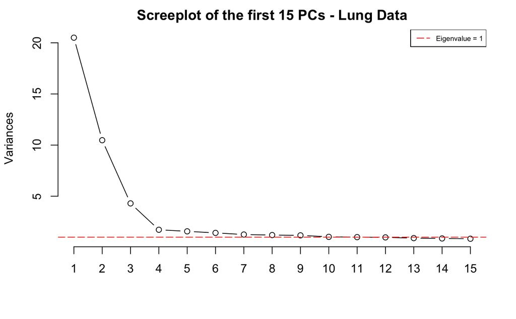

```r
legend("topright", legend=c("Eigenvalue = 1"),
col=c("red"), lty=5, cex=0.6)
```

We can see that the variance in the first three principle components are much higher than the rest, but that doesn’t necessarily mean that they contain the majority of the variance for the entire matrix. We have so many (over 1,000) components that even small amount of explained variance in the smaller components can add up.

We can now plot the cumulative variance for the same first 15 principle components:

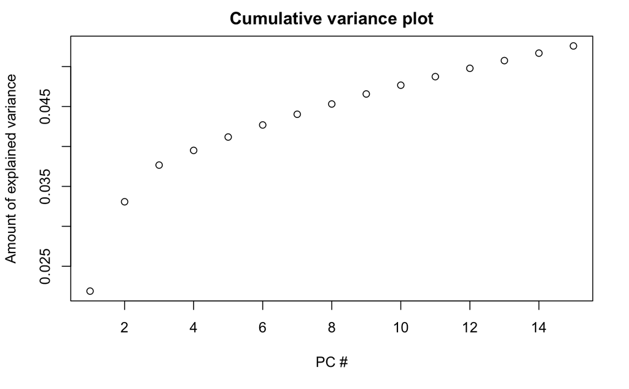

```r
cumpro <- cumsum(lung.pc.eigen.cor$sdev^2 / sum(lung.pc.eigen.cor $sdev^2))
plot(cumpro[0:15], xlab = "PC #", ylab = "Amount of explained variance", main = "Cumulative variance plot")
```

And here indeed we can see that although there are much larger amounts of explained variance in the first three components, the cumulative explained variance for all three components is only ~0.038, or 3.8% of the explained variance. This just goes to show that although PCA can find the principle components that explain the most variance, you are often still losing a lot of information from the original matrix if you only use a handful of principle components.

At this point we can plot the first two principle components against one another to visualize them:

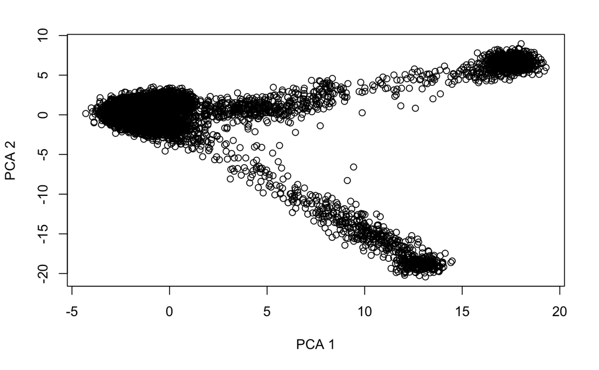

```r
plot(lung.scores.eigen[,1], lung.scores.eigen[,2], xlab="PCA 1", ylab="PCA 2")
```

We know that the last 505 samples include demographic information for three different populations (Europe, Africa, and Asia). We can extract and isolate the components representing each different population here:

```r
par(oma=c(0,0,2,0))
plot(lung.scores.eigen[1:2830,1], lung.scores.eigen[1:2830,2],
     type="p",col="black",pch=1,xlab="PC1", ylab="PC2",
     xlim = range(lung.scores.eigen[,1]),
     ylim = range(lung.scores.eigen[,2]));

points(lung.scores.eigen[19662:19826,1], lung.scores.eigen[19662:19826,2], col="red",pch=20);
```

```r
points(lung.scores.eigen[19827:19963,1], lung.scores.eigen[19827:19963,2], col="green",pch=20)
points(lung.scores.eigen[19964:20166,1], lung.scores.eigen[19964:20166,2], col="blue",pch=20)
```

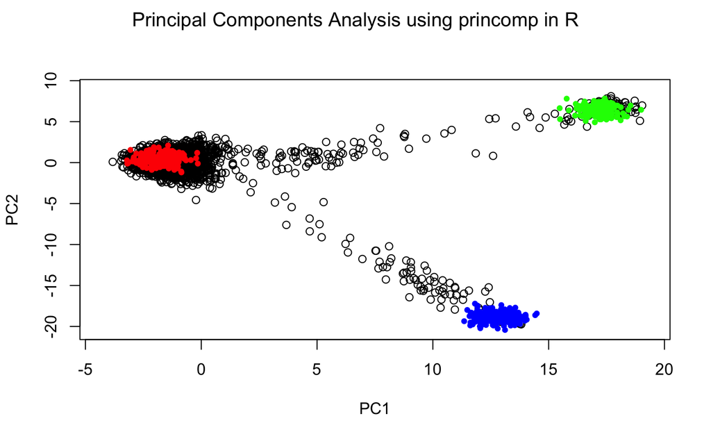

```r
title(main="Principal Components Analysis using princomp in R", col.main="black", font.main=1,outer=T)
```

Now that we see our clusters, we can find the centroids of each one by taking the mean of only the data in that cluster:

```r
lung.euro.centroid <- apply(lung.scores.eigen[19662:19826,1:2], 2, mean)
lung.asian.centroid <- apply(lung.scores.eigen[19827:19963,1:2], 2, mean)
lung.african.centroid <- apply(lung.scores.eigen[19964:20166,1:2],2,mean)

print('The centroid for the European region is:')
```

```
[1] "The centroid for the European region is:"
```

```r
print(lung.euro.centroid)
```

```
      PC1       PC2
-1.736351  0.390416
```

```r
print('The centroid for the Asian region is:')
```

```
[1] "The centroid for the Asian region is:"
```

```r
print(lung.asian.centroid)
```

```
      PC1       PC2
17.177547  6.374995
```

```r
print('The centroid for the African region is:')
```

```
[1] "The centroid for the African region is:"
```

```r
print(lung.african.centroid)
```

```
      PC1       PC2
 12.80415 -18.83316
```

Now that we have our cluster centroids, we can associate each of our remaining 19,661 samples with its closest centroid based on the distance to each cluster.

Here I define a helper function that calculates the euclidean distance given two points. The first point **p1** will be the point gathered from the first two principal components of the sample that we want to cluster. The second point **p2** will be the centroid of one of the three clusters found above.

```r
find.distance = function(p1, p2) {
  x1 = p1[1]
  y1 = p1[2]
  x2 = p2[1]
  y2 = p2[2]

  d = sqrt( ((x2 - x1)^2) + ((y2 - y1)^2) )
  return(d)
}
```

Now that we have a helper function that can find the Euclidean distance between two points, we can use that to associate a given point with either the European centroid, the Asian centroid, or the African centroid. This *cluster.data* function can then be run each of the remaining 19,661 samples so we can associate each one with it’s closest centroid.

```r
cluster.data = function(point, euro.centroid, asian.centroid, african.centroid) {
  # print(point)
  # print(euro.centroid)
  # print(asian.centroid)
  # print(african.centroid)

  # determine Euclidean distance between the point and each cluster centroid
  d_euro = find.distance(p1=point, p2=euro.centroid)
  d_asia = find.distance(p1=point, p2=asian.centroid)
  d_africa = find.distance(p1=point, p2=african.centroid)

  if ((d_euro < d_asia) & (d_euro < d_africa)) {
    # print('This point belongs to the European cluster!')
    return(1)
    } else if ((d_asia < d_euro) & (d_asia < d_africa)) {
    # print('This point belongs to the European cluster!')
    return(2)
    } else if  ((d_africa < d_euro) & (d_africa < d_asia)) {
    # print('This point belongs to the European cluster!')
    return(3)
    } else {
    print('Two or more clusters are equidistant... we should never get here!')
}

}
```

And at last we now have everything we need in order to associate the remaining 19,661 samples with one of the three cluster centroids. Here we can iterate through each sample and extract the values from the first two principle components, I do that be calling `remaining_points` which is a variable that contains the remaining 19,661 principle components that need to be sorted. I then call the above function that finds the closest centroid for each sample, then I add the sample to a bucket that corresponds to its closest centroid.

Just for good measure, I also keep count of how many samples are associated with each cluster centroid and print that below as well.

```r
remaining_points <- lung.scores.eigen[0:19661,1:2]

euro_points <- list()
asia_points <- list()
africa_points <- list()

euro = 0
asia = 0
africa = 0

# iterate through 19661 samples
for(i in 1:19661){
  c_number <- cluster.data(point = remaining_points[i,],
                   euro.centroid = lung.euro.centroid,
                   asian.centroid = lung.asian.centroid,
                   african.centroid = lung.african.centroid)
  if (c_number == 1){
    euro = euro + 1
    euro_points <- c(euro_points, c(remaining_points[i,][1], remaining_points[i,][2]))
  }
  else if (c_number == 2){
      asia = asia + 1
      asia_points <- c(asia_points, c(remaining_points[i,][1], remaining_points[i,][2]))
      # print(c(remaining_points[i,][1], remaining_points[i,][2]))
  } else{
    africa = africa + 1
    africa_points <- c(africa_points, c(remaining_points[i,][1], remaining_points[i,][2]))
  }
}
```

And with that finished, we now have our buckets filled with the points that are closest to each cluster centroid! Let’s examine how many points there were in each bucket:

```r
print(glue('The number of samples that were closest to the European centroid: {euro}'))
```

```
The number of samples that were closest to the European centroid: 18427
```

```r
print(glue('The number of samples that were closest to the Asian centroid: {asia}'))
```

```
The number of samples that were closest to the Asian centroid: 872
```

```r
print(glue('The number of samples that were closest to the African centroid: {africa}'))
```

```
The number of samples that were closest to the African centroid: 362
```

And here we can see a large disparity in the number of points that were closest to each centroid. That leads me to believe that the subjects samples for this study came mostly from continental Europe. Now we can concatenate the vectors of values in each of the lists (buckets) that represent each cluster center so we can move on to plotting.

```r
asia_array<-matrix(asia_points, nrow=c(asia, 2)[1], byrow=TRUE)
europe_array<-matrix(euro_points, nrow=c(euro, 2)[1], byrow=TRUE)
africa_array<-matrix(africa_points, nrow=c(africa, 2)[1], byrow=TRUE)
```

Great, now we can finally use the plotting code from class so generate the new plot in which each point is color coded and associated with a cluster center!

```r
par(oma=c(0,0,2,0))
plot(lung.scores.eigen[1:2830,1], lung.scores.eigen[1:2830,2],
     type="p",col="white",pch=1,xlab="PC1", ylab="PC2",
     xlim = range(lung.scores.eigen[,1]),
     ylim = range(lung.scores.eigen[,2]));

points(asia_array[, 1], asia_array[, 2], col="green",pch=20);
```

```r
points(europe_array[, 1], europe_array[, 2], col="red",pch=20);
points(africa_array[, 1], africa_array[, 2], col="blue",pch=20);
```

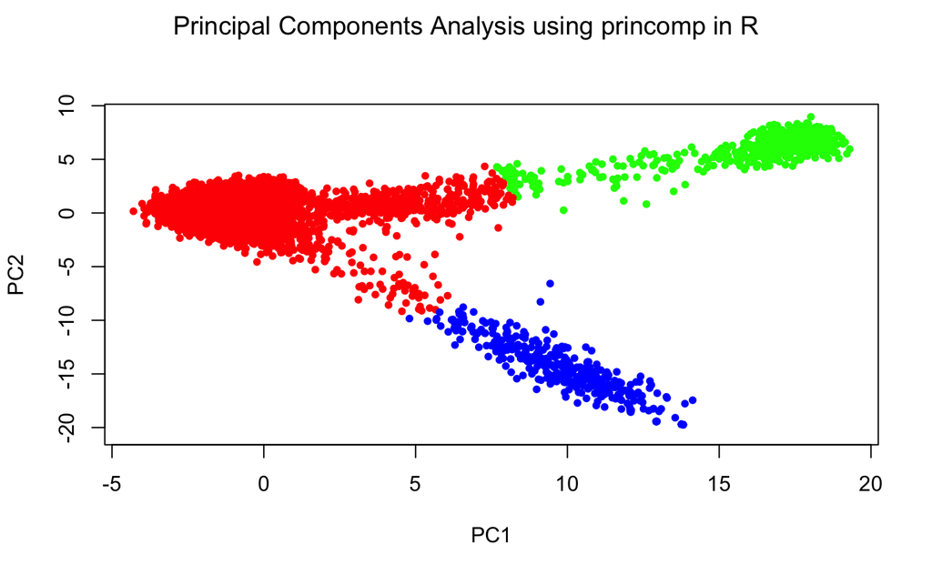

```r
title(main="Principal Components Analysis using princomp in R", col.main="black", font.main=1,outer=T)
```